# Estadística descriptiva en R

Jaime Mosquera Gutiérrez

2020-02-03

# Datos de los estudiantes

En este ejercicio vamos a trabajar con una muestra aleatoria de una *gran* base de datos. La base original corresponde a la información de 202 estudiantes de la Universidad de Antioquia. Dicha base contiene las variables: MASA (en kg), **ESTATURA** (en cm. del estudiante), **GENERO** (HOMBRE o MUJER), **ESTRATO** y **FUMA** (SI o NO).

# Extracción de la muestra

Vamos a extraer una muestra de tamaño 80 de la base de datos original. Los datos originales están en el archivo `datos_taller.txt`. el cual puede descargarlos directamente desde un repositorio de Git Hub:

```r
# Importar desde Git Hub
myURL <-
  "https://raw.github.com/Jaimemosg/EstadisticaDescriptiva/master/datos_taller.txt"
library(readr)
datos_full <- read_table2(myURL)
```

También está disponible en [Google Drive](https://drive.google.com/file/d/1LblKMIJ5FB-YUS5L7S6blKgnKRB33XpV/view?usp=sharing), si desea descargarlo para importarlo localmente:

```r
# Importar datos localmente
datos_full <- read.table(file.choose(), header = T)
```

Para crear la muestra, ejecute las siguientes líneas:

```r
# Función para extraer la muestra
muestra <- function(clave){
set.seed(clave)
data <- datos_full[sample(1:200,80),]
return(data)
}

# Para crear la base de datos, ejecutamos la función
clave <- 21368123
datos <- muestra(clave)
```

`clave` representa la semilla para generar **siempre** el mismo vector de números aleatorios. Esto garantiza que a todos nos funcione el ejercicio igual.

En este ejercicio, vamos a trabajar con varios paquetes. Copie y pegue en su consola de `R` la siguiente líneas para instalarlos:

```r
install.packages(c("Rcmdr", "RcmdrMisc", "tidyverse", "agricolae"))
```

Ahora, puede cargar los paquetes. Ignore los *warnings* que le aparezcan.

```r
library(RcmdrMisc)
library(tidyverse)
```

Los paquetes anteriores son útiles para trabajar con líneas de código dentro de un script. Si desea apoyarse con la incerfaz de RCommander (recomendable), cargue el paquete que abre dicha interfaz:

```r
library(Rcmdr)
```

# Preguntas

Usando la base de datos generada a partir de la muestra, responda a las siguientes preguntas:

1. Para las variables MASA y ESTATURA, calcule: Media, Mediana y desviación estándar e interprete sus resultados en el contexto de la información.

Dentro del paquete **base**, `R` posee una función que calcula algunos estadísticos descriptivos:

```r
# Resumen numérico del paquete Base
summary(datos)
```

```
##       MASA          ESTATURA        GENERO             ESTRATO
##  Min.   :40.00   Min.   :150.0   Length:80          Min.   :1.000
##  1st Qu.:55.75   1st Qu.:163.8   Class :character   1st Qu.:2.000
##  Median :63.50   Median :170.0   Mode  :character   Median :3.000
##  Mean   :63.48   Mean   :169.8                      Mean   :2.587
##  3rd Qu.:68.50   3rd Qu.:176.2                      3rd Qu.:3.000
##  Max.   :90.00   Max.   :187.0                      Max.   :6.000
##      FUMA
##  Length:80
##  Class :character
##  Mode  :character
##
##
##
```

Por otro lado, **RCommander** tiene una función que calcula incluso más medidas descriptivas. Esta función se ajusta perfectamente a los requerimientos de la pregunta:

```r
# Resumen numérico con RCommander
numSummary(datos[,c("ESTATURA", "MASA"), drop=FALSE], statistics=c("mean",
           "sd", "IQR", "quantiles"), quantiles=c(0,.25,.5,.75,1))
```

```
##               mean        sd   IQR  0%    25%   50%    75% 100%  n
## ESTATURA 169.77500  8.895988 12.50 150 163.75 170.0 176.25  187 80
## MASA      63.47625 11.377106 12.75  40  55.75  63.5  68.50   90 80
```

Concluya bajo el contexto de la información.

Para consultar la documentación de cualquier función, puede hacerlo cargando el paquete donde está alojada y luego debe invocarla escribiendo antes `?`

```r
# Abrir la documentación de esta función
?numSummary
```

A continuación, vamos a graficar la distribución de los datos de la **ESTATURA** mediante un histograma (izquierda) y un gráfico de densidad (derecha):

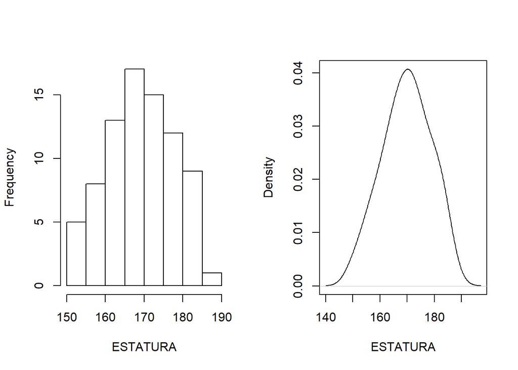

```r
par(mfrow=c(1,2))                       # genera dos espacios dentro de una ventana
with(datos, hist(ESTATURA, main = ""))  # grafica el histograma
with(datos, plot(density(ESTATURA),
                 main = "", xlab = "ESTATURA"))  # genera gráfico de densidad
```

¿Existe sesgo?¿Hacia qué dirección?

**EJERCICIO** Grafique en su consola de `R` las mismas figuras para la variable **MASA**.

2. Para la variable **ESTRATO**, elabore una tabla de porcentajes y el respectivo gráfico. Comente los resultados obtenidos en el gráfico.

Observemos el tipo de variables que hay en el marco de datos (*data frame*):

```r
sapply(datos, FUN = class)
```

```
##        MASA    ESTATURA      GENERO     ESTRATO        FUMA
##   "numeric"   "numeric" "character"   "numeric" "character"
```

Como podemos observar, la variable **ESTRATO** fue detectada como numérica, pero sabemos que en la práctica el concepto que representa se relaciona con las variables categóricas. Para solucionar este problema, vamos a *coercionar* la variable, para que sea de tipo *factor*. Esta es una estructura de datos que refleja el comportamiento de una variable categórica:

```r
datos$ESTRATO <- as.factor(datos$ESTRATO)
levels(datos$ESTRATO)
```

```
## [1] "1" "2" "3" "4" "5" "6"
```

con la función `levels` usted podrá ver las categorías que pertenecen a las variables de tipo *factor*. Con la variable como factor, puede construir la tabla de frecuencia absoluta con `xtabs`:

```r
xTabla_Estrato <- xtabs(~ESTRATO, data = datos)
xTabla_Estrato
```

```
## ESTRATO
##  1  2  3  4  5  6
##  7 30 35  6  1  1
```

```r
class(xTabla_Estrato)
```

```
## [1] "xtabs" "table"
```

Observe que la tabla es un objeto de clase *xtabs* y *table*. Con la función `table` también puede construir la tabla de frecuencia absoluta:

```r
Tabla_Estrato <- table(datos$ESTRATO)
Tabla_Estrato
```

```
##
##  1  2  3  4  5  6
##  7 30 35  6  1  1
```

```r
class(Tabla_Estrato)
```

```
## [1] "table"
```

La tabla es un objeto de clase *table*. Los objetos de clase *table* y *xtabs* tiene como métodos algunas operaciones matriciales. Por ello, es sencillo construir la tabla de frecuencias relativas (en porcentaje). Por ejemplo, con el objeto `xtable`:

```r
Tabla_Porcentaje <- xTabla_Estrato*100/nrow(datos)
```

Con la tabla construida, es posible realizar el gráfico correspondiente:

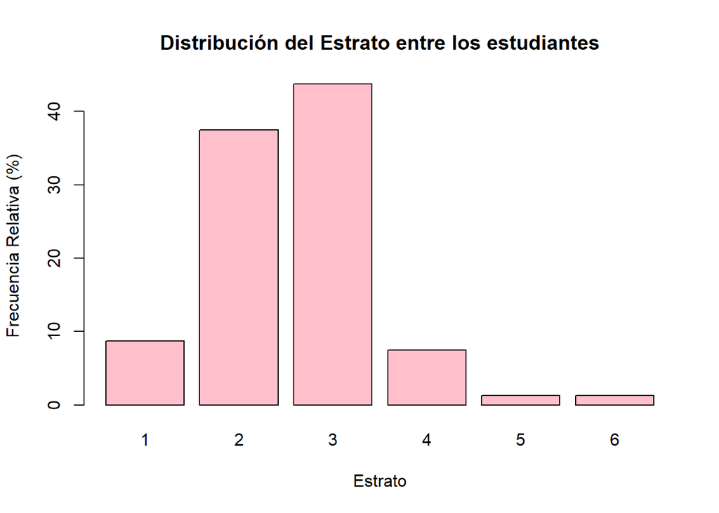

```r
barplot(Tabla_Porcentaje, xlab = "Estrato", ylab = "Frecuencia Relativa (%)", col = "pink",
        main = "Distribución del Estrato entre los estudiantes")
```

¿Por qué se realizó un gráfico de barras?

**EJERCICIO** Grafique un diagrama de barras para la variable **GENERO**.

Alternativamente, puede utilizar la función del paquete **Rcmdr** para hacer un gráfico de barras:

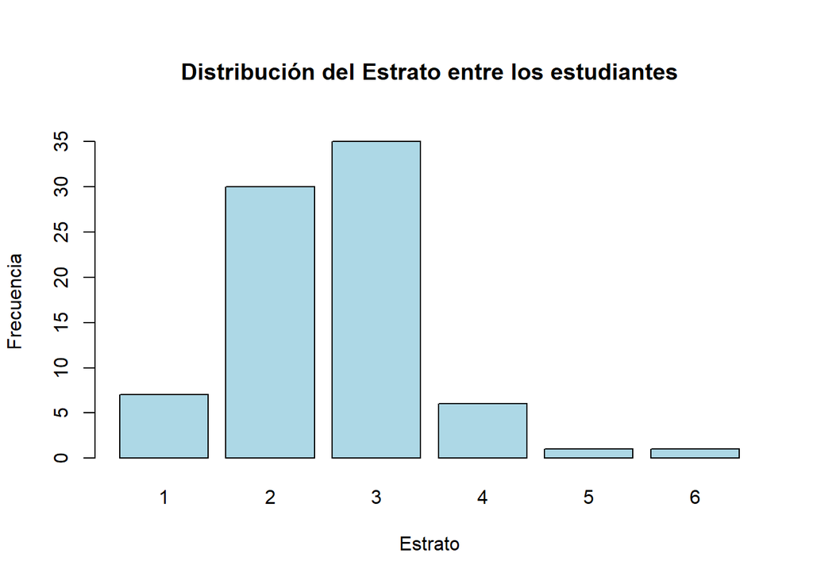

```r
with(datos, Barplot(ESTRATO, xlab = "Estrato", ylab = "Frecuencia", col = "lightblue",
                    main = "Distribución del Estrato entre los estudiantes"))
```

`barplot` (de **graphics**) tiene como argumento de entrada una tabla, la cual se puede construir con las variables cualitativas definidas como *factor* o como *character*. Por otro lado, `Barplot` (de **Rcmdr**) recibe como argumento de entrada un vector de clase `factor`. Recuerde, el resultado obtenido con `Barplot` se puede replicar también en la interfaz de RCommander.

3. Si se considera la variable ESTATURA, ¿Esta se comporta igual en los hombres y mujeres? Justifique su respuesta. Elabore los gráficos que considere pertinentes. Estos deben ser interpretados, en el contexto de la información analizada.

El *boxplot* muestra el comportamiento de la distribución de datos, agrupada en las categorías que se especifiquen. Veamos:

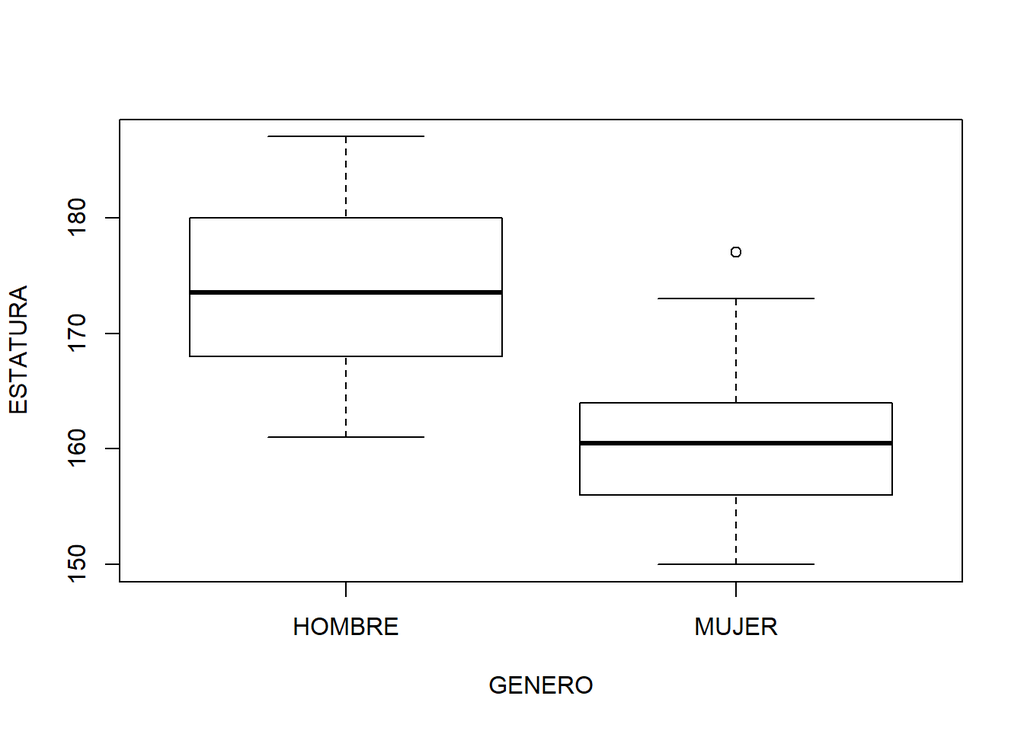

```r
# Paquete graphics
boxplot(ESTATURA ~ GENERO, data = datos)
```

¿Cómo se puede describir la distribución de la **ESTATURA** en hombres respecto a mujeres?

**EJERCICIO** El gráfico anterior se generó con el paquete **graphics**, que está preinstalado en `R`. Grafique un boxplot en RCommander.

La respuesta puede complementarse con otros gráficos descriptivos, pero se debe ser cuidadoso con las *ilusiones gráficas*.

## Gráficas simultáneas

**Rcmdr** permite graficar histogramas de forma simultánea, de acuerdo con las categorías de una variable cualitativa:

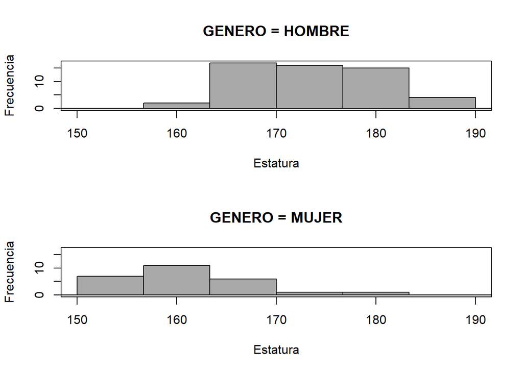

```r
# Con RCommander
datos$GENERO <- as.factor(datos$GENERO)
H <- with(datos, Hist(ESTATURA, groups = GENERO, scale = "frequency",
                      breaks = "Sturges", col = "darkgray", xlab = "Estatura",
                      ylab = "Frecuencia"))
```

Si observa detalladamente, los límites de los intervalos de clase se acomodan justo igual para ambas categorías. Vamos a imprimir sus valores calculados:

```r
# Límites del histograma de 'Rcmdr'
H$MUJER$breaks
```

```
## [1] 150.0000 156.6667 163.3333 170.0000 176.6667 183.3333 190.0000
```

Repliquemos este mismo tipo de gráfica con el paquete **ggplot2** de **tidyverse**:

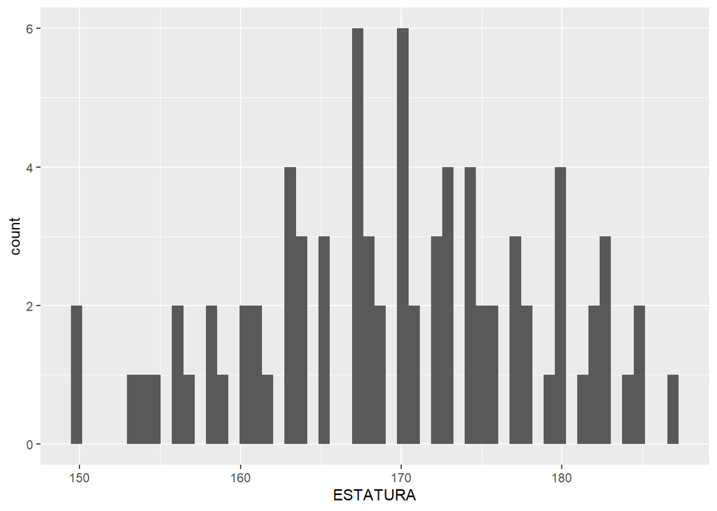

```r
ggplot(data = datos, mapping = aes(x = ESTATURA)) +
  geom_histogram(binwidth = 0.7)
```

En **ggplot2**, cada función que se aplica tiene argumentos de entrada que modifican el gráfico:

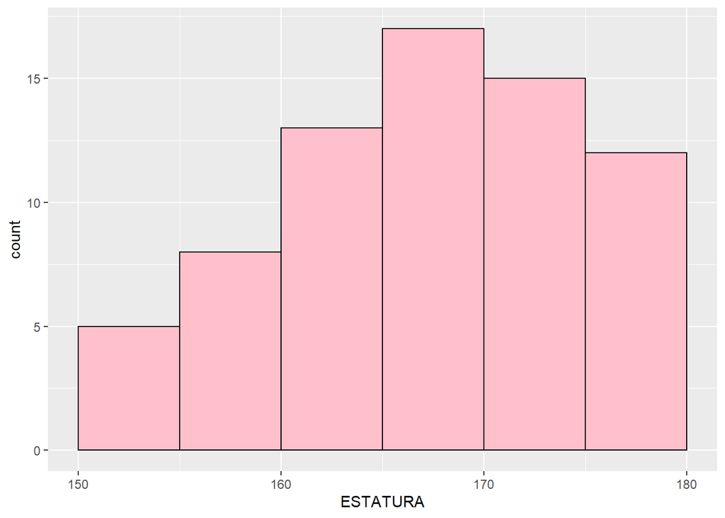

```r
ggplot(data = datos, mapping = aes(x = ESTATURA)) +
  geom_histogram(color = "black", fill = "pink", breaks = seq(150, 180, by = 5))
```

A su vez, cada función que adicione va modificando el gráfico. Por ejemplo, `facet_grid` es una función que genera dos gráficos según la variable categórica de agrupación que se especifique:

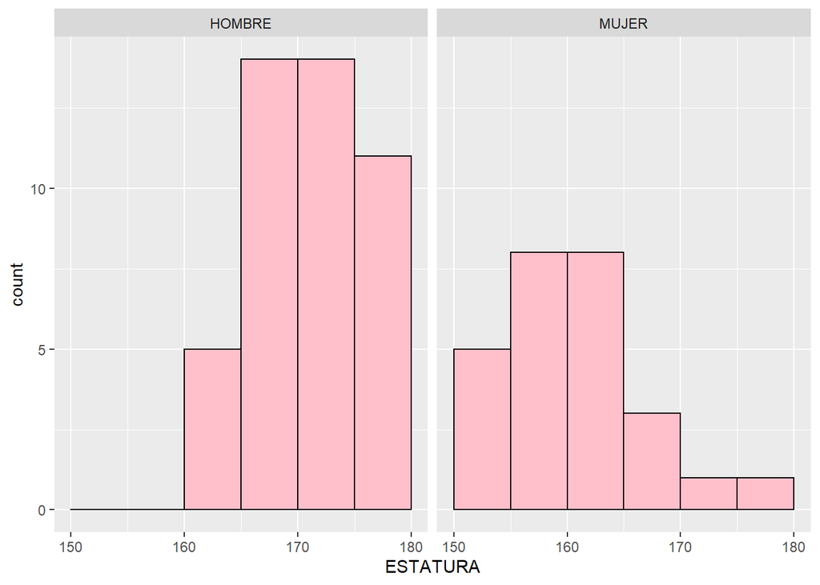

```r
ggplot(data = datos, mapping = aes(x = ESTATURA)) +
  geom_histogram(color = "black", fill = "pink", breaks = seq(150, 180, by = 5)) +
  facet_grid(. ~ GENERO)
```

`theme_bw` cambia el fondo del gráfico:

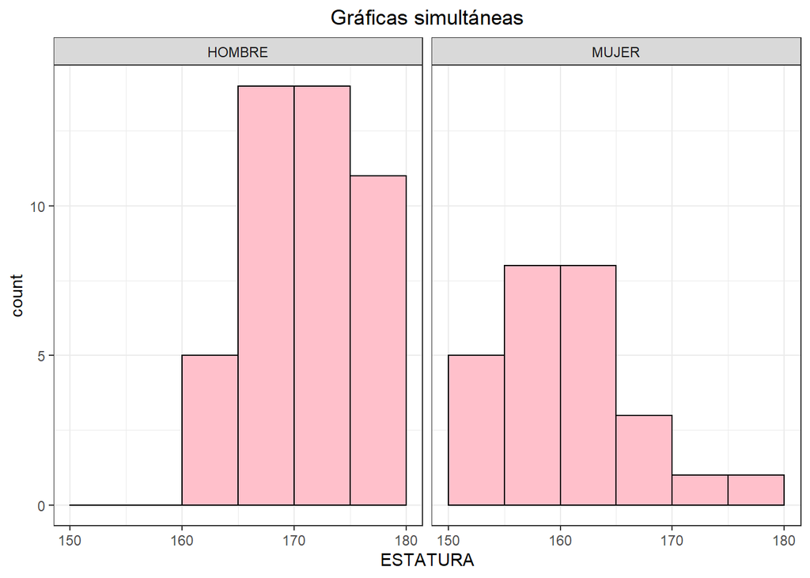

```r
ggplot(data = datos, mapping = aes(x = ESTATURA)) +
  geom_histogram(color = "black", fill = "pink", breaks = seq(150, 180, by = 5)) +
  facet_grid(. ~ GENERO) +  theme_bw() + ggtitle("Gráficas simultáneas") +
  theme(plot.title = element_text(hjust = 0.5))
```

De forma similar, se pueden graficar las densidades:

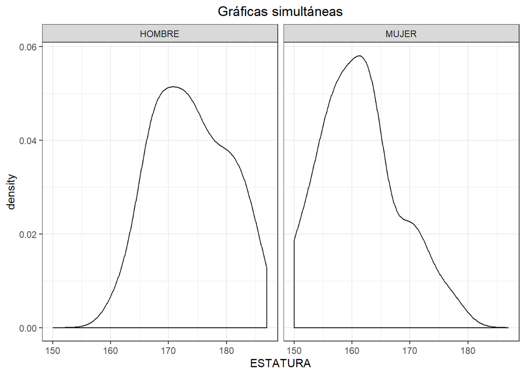

```r
ggplot(data = datos, mapping = aes(x = ESTATURA)) +
  geom_density() +
  theme_bw() + facet_grid(. ~ GENERO) + ggtitle("Gráficas simultáneas") +
  theme(plot.title = element_text(hjust = 0.5))
```

## Gráficas separadas

Sea con **Rcmdr** o con **ggplot2**, se forzó a que ambas categorías de **GENERO** tuvieran los mismos intervalos de clase. Ahora, grafiquemos de manera independiente:

```r
datosF <- datos %>% filter(GENERO == "MUJER")  # Filtramos la distribución de mujeres
datosM <- datos %>% filter(GENERO == "HOMBRE") # Filtramos la distribución de hombres

# Comparamos media y mediana (sesgo)
print("MUJERES")
```

```
## [1] "MUJERES"
```

```r
numSummary(datosF[,c("ESTATURA"), drop=FALSE], statistics=c("mean",
                "sd", "IQR", "quantiles"), quantiles=c(0,.25,.5,.75,1))
```

```
##      mean       sd  IQR  0%    25%   50% 75% 100%  n
##  161.1923 6.829461 7.75 150 156.25 160.5 164  177 26
```

```r
print("HOMBRES")
```

```
## [1] "HOMBRES"
```

```r
numSummary(datosM[,c("ESTATURA"), drop=FALSE], statistics=c("mean",
                  "sd", "IQR", "quantiles"), quantiles=c(0,.25,.5,.75,1))
```

```
##      mean       sd  IQR  0%    25%   50%    75% 100%  n
##  173.9074 6.513465 11.5 161 168.25 173.5 179.75  187 54
```

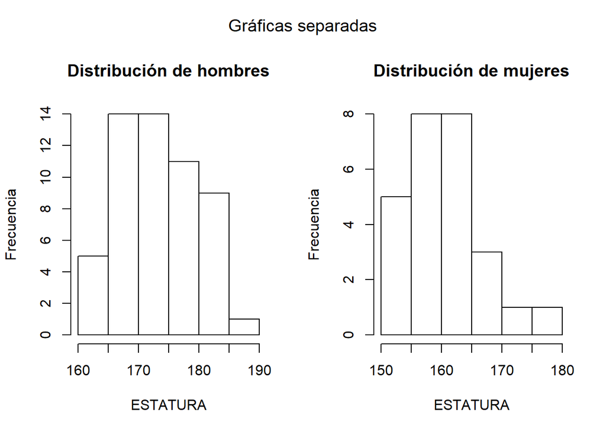

```r
par(mfrow = c(1,2), oma = c(0, 0, 2, 0))
with(datosM, hist(ESTATURA, main = "Distribución de hombres",
                  ylab = "Frecuencia"))
with(datosF, hist(ESTATURA, main = "Distribución de mujeres",
                  ylab = "Frecuencia"))
mtext("Gráficas separadas", outer = TRUE, cex = 1.2)
```

Compare la distribución de los hombres de las gráficas simultáneas con la distribución de las gráficas separadas. ¿Son coherentes las gráficas independientes con las simultáneas?

**EJERCICIO** Repita la graficacación simultánea y separada con la variable **MASA**, y compare.

4. ¿Es la MASA promedio de los que fuman inferior a la MASA promedio de los que no fuman? ¿Existen datos atípicos? ¿Cómo se interpretan estos? Justifique sus respuestas con gráficos y tablas.

Los estadísticos descriptivos son útiles para responder la primera pregunta:

```r
numSummary(datos[,"MASA", drop=FALSE], groups=datos$FUMA,
           statistics=c("mean", "sd", "IQR", "quantiles"), quantiles=c(0,.25,.5,.75,1))
```

```
##        mean       sd   IQR 0%   25% 50%   75% 100% MASA:n
## NO 63.01486 11.20101 12.75 40 55.25  62 68.00   90     74
## SI 69.16667 13.09071 11.75 50 64.50  67 76.25   88      6
```

Además, se puede representar el promedio gráficamente:

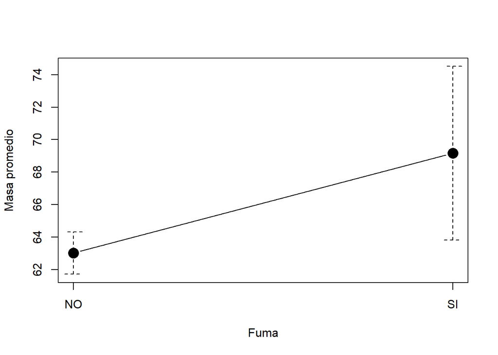

```r
datos$FUMA <- as.factor(datos$FUMA)
with(datos, plotMeans(MASA, FUMA, error.bars="se", xlab="Fuma",
                      ylab="Masa promedio", main="", connect=TRUE))
```

Recuerde, los datos atípicos se pueden detectar con un *boxplot*

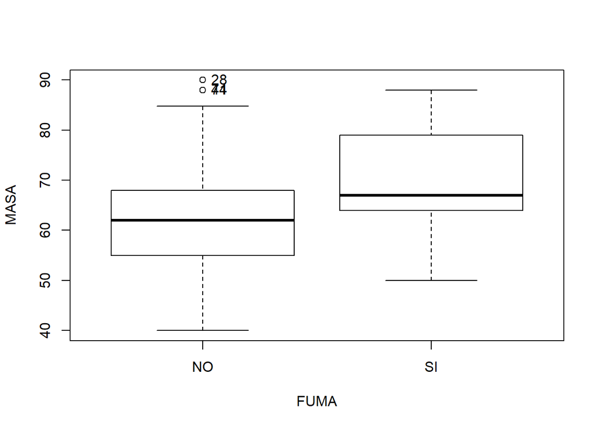

```
## [1] "28" "44" "71"
```

```r
# Boxplot de RCommander
Boxplot(MASA~FUMA, data=datos, id=list(method="y"))
```

Concluya bajo el contexto de la información.

5. ¿Se puede afirmar que el porcentaje de personas que Fuman es mayor en Hombres que en Mujeres? Justifique su respuesta.

Basta con realizar una tabla de contingencia para responder esta pregunta:

```r
Conteo <- xtabs(~FUMA+GENERO, data=datos)
Porcentajes <- totPercents(Conteo, digits = 2)
Porcentajes
```

```
##       HOMBRE MUJER Total
## NO      60.0  32.5  92.5
## SI       7.5   0.0   7.5
## Total   67.5  32.5 100.0
```

¿Por qué razón se sabe claramente que esta pregunta se responde con este tipo de tabla?

**BONUS** La tabla de contingencia también se puede representar graficamente:

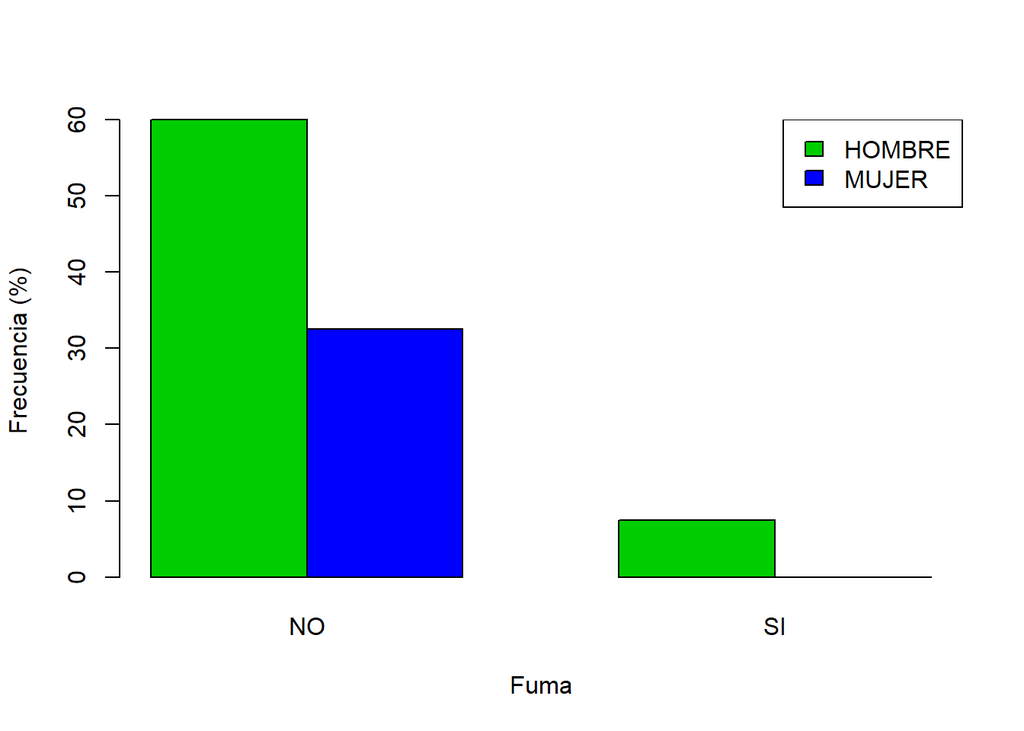

```r
barplot(t(Porcentajes[1:2,1:2]), beside = T, col = 3:4, xlab = "Fuma", ylab = "Frecuencia (%)")
legend("topright", legend = colnames(Porcentajes[1:2,1:2]), fill = 3:4)
```

6. ¿Qué cantidad de estudiantes tienen una estatura igual o menor a 170 cm? ¿Qué porcentaje representan?

La pregunta pregunta por los datos *iguales o menores a…*. Esto es un indicativo de que se puede responder sobre la base de la frecuencia acumulada. Para ello, resulta útil la *ojiva*:

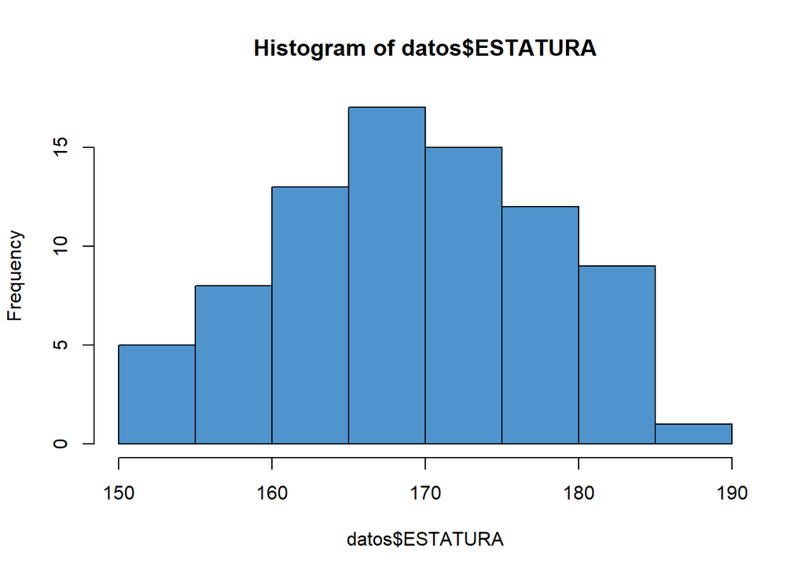

```r
h <- hist(datos$ESTATURA, col = "Steelblue3")
```

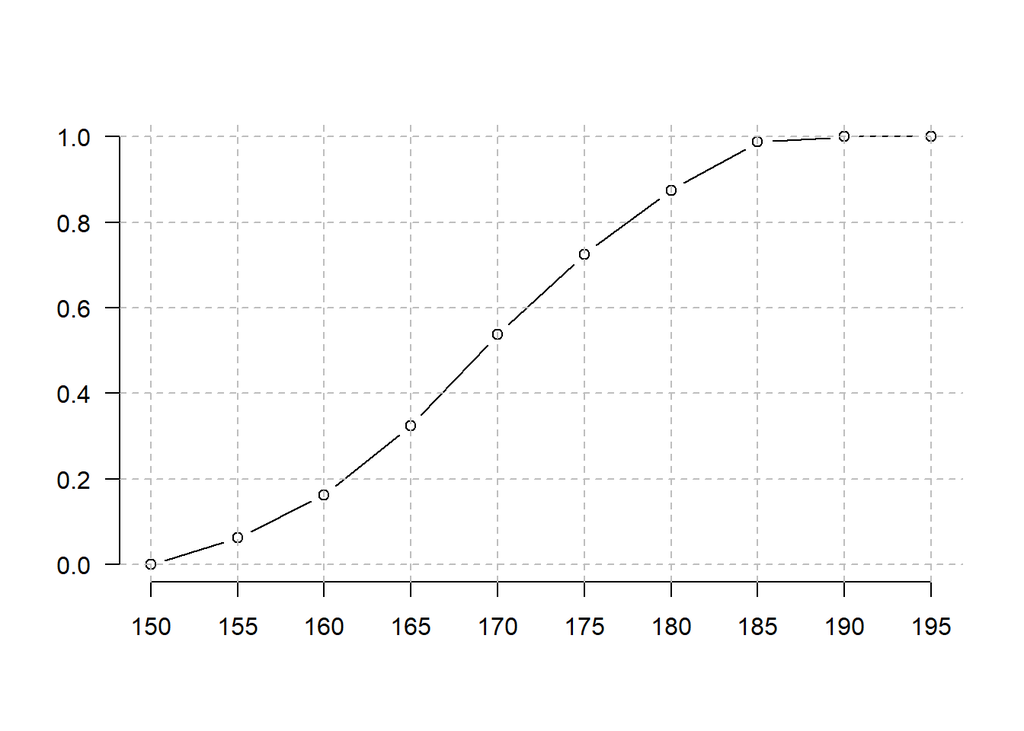

```
##      x    RCF
## 1  150 0.0000
## 2  155 0.0625
## 3  160 0.1625
## 4  165 0.3250
## 5  170 0.5375
## 6  175 0.7250
## 7  180 0.8750
## 8  185 0.9875
## 9  190 1.0000
## 10 195 1.0000
```

```r
library(agricolae)
ogive.freq(h)
```

También puede construir una tabla frecuencias. Puede hacerlo revisando el siguiente [enlace](https://www.r-tutor.com/elementary-statistics/quantitative-data/frequency-distribution-quantitative-data)

*Sobre la base del procedimiento de la pregunta anterior, responda la siguiente:*

7. ¿Qué porcentaje de estudiantes mujeres tienen una MASA mayor a 55 kg?